# Regression_bike-sharing

2018/07/25

[figure not shown]

#### 假設檢定

1. T-Test
- 所有的假設(null hypothesis)都是建立在“等於”上(平等)
- p<0.05 p夠小表示反駁的證據足夠(95%)，推翻等於假設 => 顯著(有相異性)
- p>0.05 p太大表示證據不足(<95%)，無法推翻等於假設 => 不顯著(無相異性)
2. ANOVA（Analysis of variance）變異數分析
- 適用於多變數,不必做多次T-Test
- 探討 *連續型* 變數與 *類別型* 變數的關係

### **1. Import Library**

```r
library(tidyverse)
library(ggplot2)
library(plotly)
```

### **2. 讀入資料**

此資料集收集了2011~2012年Washington D.C.的Capital Bikeshare 共享單車每天使用量紀錄，並輔以天氣和季節性等數據

欄位簡介

- `instant`: record index
- `dteday` : date
- `season` : season (1:springer, 2:summer, 3:fall, 4:winter)
- `yr` : year (0: 2011, 1:2012)
- `mnth` : month ( 1 to 12)
- `holiday` : weather day is holiday or not
- `weekday` : day of the week
- `workingday` : if day is neither weekend nor holiday is 1, otherwise is 0.
- `weathersit` :
  - 1: Clear, Few clouds, Partly cloudy, Partly cloudy
  - 2: Mist + Cloudy, Mist + Broken clouds, Mist + Few clouds, Mist
  - 3: Light Snow, Light Rain + Thunderstorm + Scattered clouds, Light Rain + Scattered clouds
  - 4: Heavy Rain + Ice Pallets + Thunderstorm + Mist, Snow + Fog
- `temp` : Normalized temperature in Celsius. The values are divided to 41 (max)
- `atemp`: Normalized feeling temperature in Celsius. The values are divided to 50 (max)
- `hum`: Normalized humidity. The values are divided to 100 (max)
- `windspeed`: Normalized wind speed. The values are divided to 67 (max)
- `casual`: count of casual users
- `registered`: count of registered users
- `cnt`: count of total rental bikes including both casual and registered

```r
df <- read.csv('./data/Bike-Sharing-Dataset/day.csv')

df$season <- factor(df$season)
df$yr <- factor(df$yr)
df$mnth <- factor(df$mnth)
df$holiday <- factor(df$holiday)
df$weekday <- factor(df$weekday)
df$workingday <- factor(df$workingday)
df$weathersit <- factor(df$weathersit)

df %>% summary()
```

```
##     instant             dteday    season  yr           mnth     holiday
##  Min.   :  1.0   2011-01-01:  1   1:181   0:365   1      : 62   0:710
##  1st Qu.:183.5   2011-01-02:  1   2:184   1:366   3      : 62   1: 21
##  Median :366.0   2011-01-03:  1   3:188           5      : 62
##  Mean   :366.0   2011-01-04:  1   4:178           7      : 62
##  3rd Qu.:548.5   2011-01-05:  1                   8      : 62
##  Max.   :731.0   2011-01-06:  1                   10     : 62
##                  (Other)   :725                   (Other):359
##  weekday workingday weathersit      temp             atemp
##  0:105   0:231      1:463      Min.   :0.05913   Min.   :0.07907
##  1:105   1:500      2:247      1st Qu.:0.33708   1st Qu.:0.33784
##  2:104              3: 21      Median :0.49833   Median :0.48673
##  3:104                         Mean   :0.49538   Mean   :0.47435
##  4:104                         3rd Qu.:0.65542   3rd Qu.:0.60860
##  5:104                         Max.   :0.86167   Max.   :0.84090
##  6:105
##       hum           windspeed           casual         registered
##  Min.   :0.0000   Min.   :0.02239   Min.   :   2.0   Min.   :  20
##  1st Qu.:0.5200   1st Qu.:0.13495   1st Qu.: 315.5   1st Qu.:2497
##  Median :0.6267   Median :0.18097   Median : 713.0   Median :3662
##  Mean   :0.6279   Mean   :0.19049   Mean   : 848.2   Mean   :3656
##  3rd Qu.:0.7302   3rd Qu.:0.23321   3rd Qu.:1096.0   3rd Qu.:4776
##  Max.   :0.9725   Max.   :0.50746   Max.   :3410.0   Max.   :6946
##
##       cnt
##  Min.   :  22
##  1st Qu.:3152
##  Median :4548
##  Mean   :4504
##  3rd Qu.:5956
##  Max.   :8714
##
```

## Part A. 年 vs 單車租借量

### 首先從不同年份的單車租借量盒鬚圖開始，並計算其信賴區間

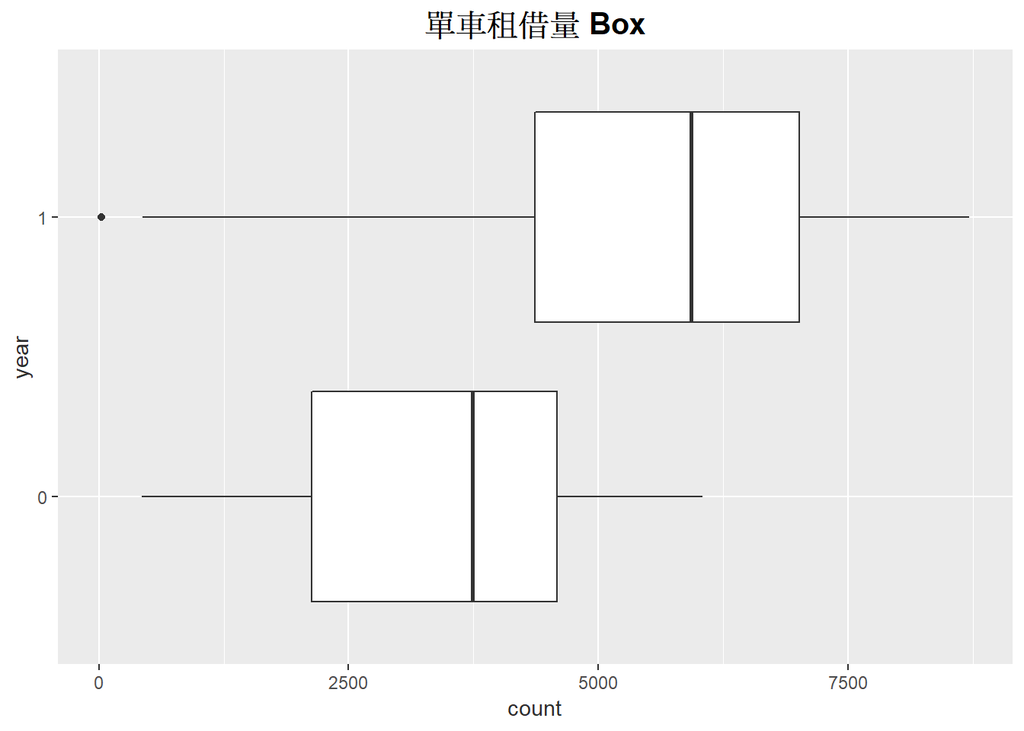

```r
ggplot(data = df, aes(x = yr, y = cnt)) +
 geom_boxplot() + coord_flip() +
 labs( y = 'count', x = 'year',
       title = '單車租借量 Box') +
  theme(axis.title = element_text(color = '#2d2d2d'),
        strip.text.x =  element_text(color='#2d2d2d',face='bold',size=10),
        plot.title = element_text(hjust=0.5,face='bold',size=15))
```

> => **推測2012的數量比2011高出許多**

```r
#以下函式計算95%信賴區間
with(df,
     tapply(cnt, yr,
     function(x)
       c(mean(x) + c(-2, 2) * sd(x)/sqrt(length(x)))))
```

```
## $`0`
## [1] 3261.427 3550.096
##
## $`1`
## [1] 5412.944 5786.925
```

### 以下用 t-test 檢驗不同年分是否存在單車租借量差異

```r
#此函數會預設進行 Welch 校正，以處理兩樣本變異數不相同的問題
t.test(cnt ~ yr, data = df)
```

```
##
##  Welch Two Sample t-test
##
## data:  cnt by yr
## t = -18.578, df = 685.5, p-value < 2.2e-16
## alternative hypothesis: true difference in means is not equal to 0
## 95 percent confidence interval:
##  -2426.069 -1962.276
## sample estimates:
## mean in group 0 mean in group 1
##        3405.762        5599.934
```

```r
#可加上參數 var.equal=TRUE 來假設變異數同值(不做Welch校正)
t.test(cnt ~ yr, data = df, var.equal = TRUE)
```

```
##
##  Two Sample t-test
##
## data:  cnt by yr
## t = -18.571, df = 729, p-value < 2.2e-16
## alternative hypothesis: true difference in means is not equal to 0
## 95 percent confidence interval:
##  -2426.126 -1962.220
## sample estimates:
## mean in group 0 mean in group 1
##        3405.762        5599.934
```

> => **p-value極小，表示年份是顯著的**  
> 可能隨著環保意識抬頭，使用共享單車的人數也越來越多

## Part B. 節日(holiday) vs 單車租借量

### 首先從不同holiday的單車租借量盒鬚圖開始，並計算其信賴區間

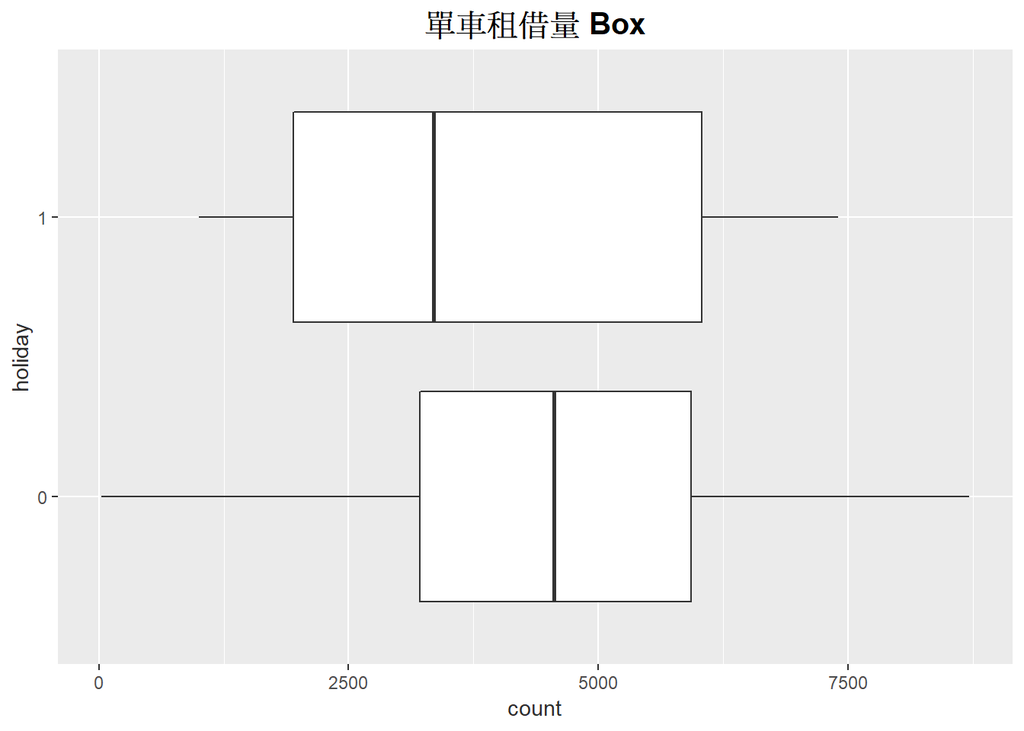

```r
ggplot(data = df, aes(x = holiday, y = cnt)) +
 geom_boxplot() + coord_flip() +
 labs( y = 'count', x = 'holiday',
       title = '單車租借量 Box') +
  theme(axis.title = element_text(color = '#2d2d2d'),
        strip.text.x =  element_text(color='#2d2d2d',face='bold',size=10),
        plot.title = element_text(hjust=0.5,face='bold',size=15))
```

> => **推測假日使用單車的人較少**

```r
#以下函式計算95%信賴區間
with(df,
     tapply(cnt, holiday,
     function(x)
       c(mean(x) + c(-2, 2) * sd(x)/sqrt(length(x)))))
```

```
## $`0`
## [1] 4382.315 4671.893
##
## $`1`
## [1] 2817.023 4652.977
```

### 以下用 t-test 檢驗節日與否是否存在單車租借量差異

```r
#此函數會預設進行 Welch 校正，以處理兩樣本變異數不相同的問題
t.test(cnt ~ holiday, data = df)
```

```
##
##  Welch Two Sample t-test
##
## data:  cnt by holiday
## t = 1.7047, df = 21.007, p-value = 0.103
## alternative hypothesis: true difference in means is not equal to 0
## 95 percent confidence interval:
##  -174.1953 1758.4038
## sample estimates:
## mean in group 0 mean in group 1
##        4527.104        3735.000
```

```r
#可加上參數 var.equal=TRUE 來假設變異數同值(不做Welch校正)
t.test(cnt ~ holiday, data = df, var.equal = TRUE)
```

```
##
##  Two Sample t-test
##
## data:  cnt by holiday
## t = 1.8497, df = 729, p-value = 0.06476
## alternative hypothesis: true difference in means is not equal to 0
## 95 percent confidence interval:
##   -48.60833 1632.81678
## sample estimates:
## mean in group 0 mean in group 1
##        4527.104        3735.000
```

> => **p-value不夠小，表示節日是不顯著的**

## Part C. 工作日(workingday) vs 單車租借量

### 首先從不同workingday的單車租借量盒鬚圖開始，並計算其信賴區間

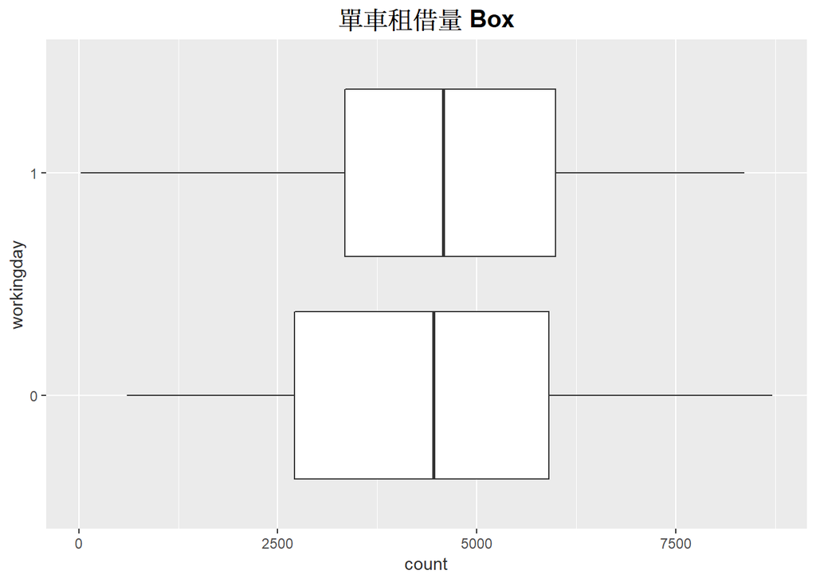

```r
ggplot(data = df, aes(x = workingday, y = cnt)) +
 geom_boxplot() + coord_flip() +
 labs( y = 'count', x = 'workingday',
       title = '單車租借量 Box') +
  theme(axis.title = element_text(color = '#2d2d2d'),
        strip.text.x =  element_text(color='#2d2d2d',face='bold',size=10),
        plot.title = element_text(hjust=0.5,face='bold',size=15))
```

```r
#以下函式計算95%信賴區間
with(df,
     tapply(cnt, workingday,
     function(x)
       c(mean(x) + c(-2, 2) * sd(x)/sqrt(length(x)))))
```

```
## $`0`
## [1] 4060.127 4600.211
##
## $`1`
## [1] 4416.809 4752.831
```

```r
#此函數會預設進行 Welch 校正，以處理兩樣本變異數不相同的問題
t.test(cnt ~ workingday, data = df)
```

```
##
##  Welch Two Sample t-test
##
## data:  cnt by workingday
## t = -1.6014, df = 413.94, p-value = 0.1101
## alternative hypothesis: true difference in means is not equal to 0
## 95 percent confidence interval:
##  -567.23982   57.93748
## sample estimates:
## mean in group 0 mean in group 1
##        4330.169        4584.820
```

```r
#可加上參數 var.equal=TRUE 來假設變異數同值(不做Welch校正)
t.test(cnt ~ workingday, data = df, var.equal = TRUE)
```

```
##
##  Two Sample t-test
##
## data:  cnt by workingday
## t = -1.6543, df = 729, p-value = 0.09849
## alternative hypothesis: true difference in means is not equal to 0
## 95 percent confidence interval:
##  -556.85395   47.55161
## sample estimates:
## mean in group 0 mean in group 1
##        4330.169        4584.820
```

> => **p-value不夠小，表示workingday是不顯著的**

## Part D. 年 & 月 vs 單車租借量

### 以下觀察 月份 是否與 單車租借量 有關

```r
#看不同 月份 下的 單車租借量 平均數
tapply(df$cnt, df$mnth, mean)
```

```
##        1        2        3        4        5        6        7        8
## 2176.339 2655.298 3692.258 4484.900 5349.774 5772.367 5563.677 5664.419
##        9       10       11       12
## 5766.517 5199.226 4247.183 3403.806
```

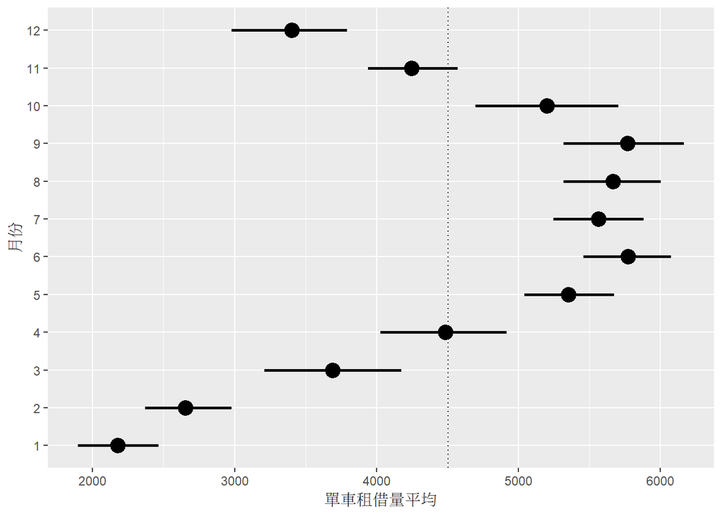

```r
library(Hmisc)

#同 月份 下的 單車租借量 平均數，加上信賴區間
ggplot(data = df,
       aes(x = mnth, y = cnt)) +
  stat_summary(fun.data = 'mean_cl_boot', size = 1) +
  scale_y_continuous(breaks = seq(2000, 6000, by = 1000)) +
  geom_hline(yintercept = mean(df$cnt) ,
             linetype = 'dotted') +
  labs(x = '月份', y = '單車租借量平均') +
  coord_flip()
```

### 在這裡我們推測 月份 的效果 可能是 年份 造成的，畫圖觀察看看

```r
anova(m1 <- lm(cnt ~ mnth, data = df))
```

```
## Analysis of Variance Table
##
## Response: cnt
##            Df     Sum Sq  Mean Sq F value    Pr(>F)
## mnth       11 1070192271 97290206  41.904 < 2.2e-16 ***
## Residuals 719 1669343121  2321757
## ---
## Signif. codes:  0 '***' 0.001 '**' 0.01 '*' 0.05 '.' 0.1 ' ' 1
```

(註: mnth表組間, Residuals表組內, Mean Sq = Sum Sq / Df, F value = Mean Sq.mnth/Mean Sq.Residuals)  
> =>**p-value極小，月份效果顯著**

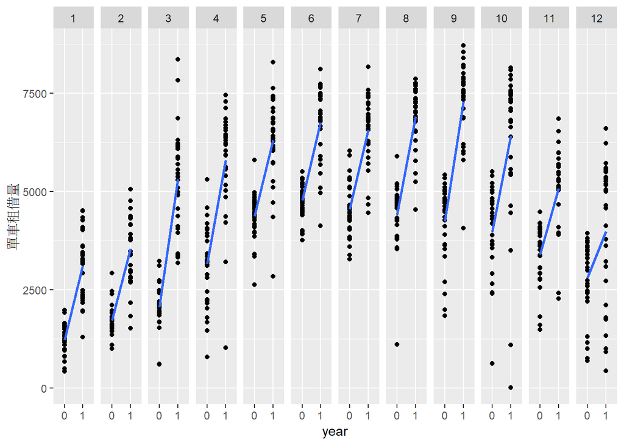

```r
ggplot(data = df,
       aes(group = mnth,
          y = cnt, x = yr)) +
  geom_point() +
  stat_smooth(method = 'lm', se = F) +
  stat_smooth(aes(group = mnth,
          y = cnt, x = yr),
          method = 'lm', se = F) +
  facet_grid( . ~  mnth) +
  labs(x = 'year', y = '單車租借量')
```

### 利用以下 ANOVA 檢驗假設是否正確

```r
#把 年份 加進模型
anova(m2 <- update(m1, . ~ . + yr, data = df))
```

```
## Analysis of Variance Table
##
## Response: cnt
##            Df     Sum Sq   Mean Sq F value    Pr(>F)
## mnth       11 1070192271  97290206  88.937 < 2.2e-16 ***
## yr          1  883910267 883910267 808.023 < 2.2e-16 ***
## Residuals 718  785432854   1093918
## ---
## Signif. codes:  0 '***' 0.001 '**' 0.01 '*' 0.05 '.' 0.1 ' ' 1
```

```r
#或許不是 月份 而是 年份 造成
anova(m3 <- update(m2, . ~ . - mnth,  data = df))
```

```
## Analysis of Variance Table
##
## Response: cnt
##            Df     Sum Sq   Mean Sq F value    Pr(>F)
## yr          1  879828893 879828893  344.89 < 2.2e-16 ***
## Residuals 729 1859706499   2551038
## ---
## Signif. codes:  0 '***' 0.001 '**' 0.01 '*' 0.05 '.' 0.1 ' ' 1
```

> =>**p-value極小，兩者效果都顯著**

### 將 ANOVA 結果做成圖表輸出，先計算一些需要的數據

```r
#將結果放在一個list中
res_lm <- lapply(list(m1, m2, m3), summary)
#比較在控制 年份 下， 父母教育 的效果
(res_lm[[2]]$r.sq - res_lm[[3]]$r.sq)/res_lm[[2]]$r.sq
```

```
## [1] 0.549753
```

```r
anova(m3, m2)
```

```
## Analysis of Variance Table
##
## Model 1: cnt ~ yr
## Model 2: cnt ~ mnth + yr
##   Res.Df        RSS Df  Sum of Sq      F    Pr(>F)
## 1    729 1859706499
## 2    718  785432854 11 1074273644 89.277 < 2.2e-16 ***
## ---
## Signif. codes:  0 '***' 0.001 '**' 0.01 '*' 0.05 '.' 0.1 ' ' 1
```

```r
#比較在控制 月份 下， 年份 的效果
(res_lm[[2]]$r.sq - res_lm[[1]]$r.sq)/res_lm[[1]]$r.sq
```

```
## [1] 0.8259359
```

```r
anova(m1, m2)
```

```
## Analysis of Variance Table
##
## Model 1: cnt ~ mnth
## Model 2: cnt ~ mnth + yr
##   Res.Df        RSS Df Sum of Sq      F    Pr(>F)
## 1    719 1669343121
## 2    718  785432854  1 883910267 808.02 < 2.2e-16 ***
## ---
## Signif. codes:  0 '***' 0.001 '**' 0.01 '*' 0.05 '.' 0.1 ' ' 1
```

### 正式畫圖

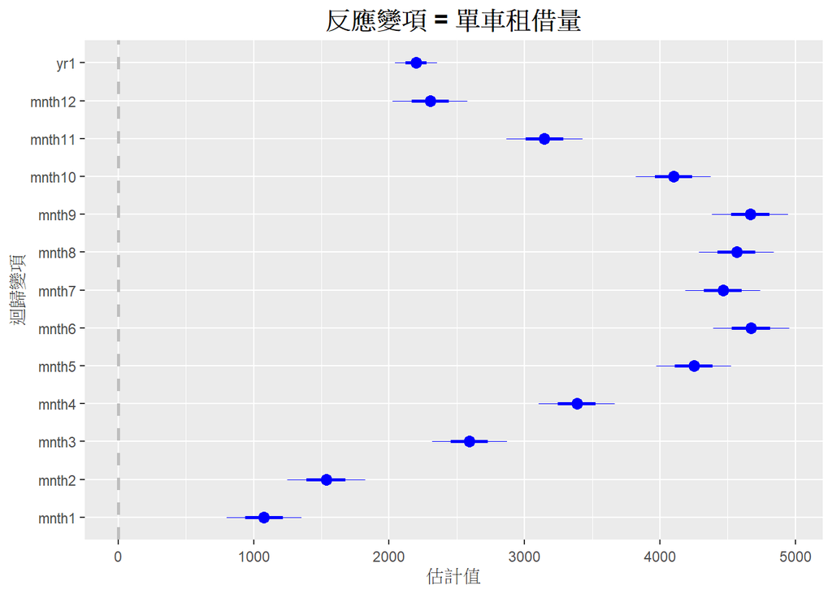

```r
require(coefplot)
m2 <- lm(cnt ~ mnth + yr -1, data = df) #(-1 將截距去除)
coefplot(m2, xlab = '估計值', ylab = '迴歸變項', title = '反應變項 = 單車租借量') +
  theme(axis.title = element_text(color = '#2d2d2d'),
        strip.text.x =  element_text(color='#2d2d2d',face='bold',size=10),
        plot.title = element_text(hjust=0.5,face='bold',size=15))
```

### 把資料與迴歸分析的預測值、殘差與影響度放進資料

```r
fit_m2 <- data.frame(df[, c(16, 5, 4)], fitted = fitted(m2), resid = resid(m2),
                     infl = influence(m2)$hat )
```

### 依 月份 疊合真實觀測值與預測值

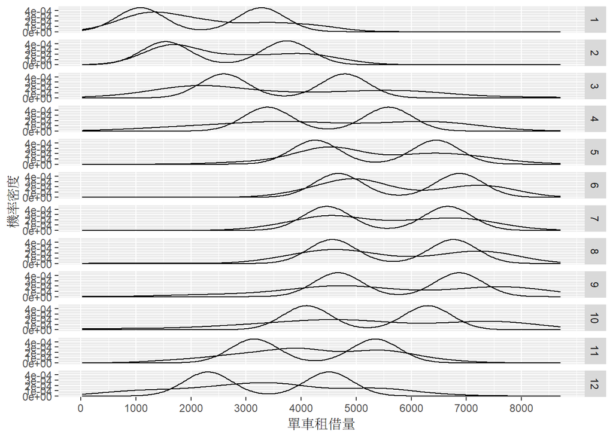

```r
ggplot(data = fit_m2, aes(x = cnt, group = mnth )) +
 stat_density(geom = 'path', position = 'identity') +
 stat_density(geom = 'path', position = 'identity', aes(x = fitted)) +
 facet_grid(mnth ~ .) +
 scale_x_continuous(breaks = seq(0, 8000, by = 1000))+
 labs(x = '單車租借量', y = '機率密度')
```

### 看殘差分配，依 月份 檢視常態與變異數同質假設

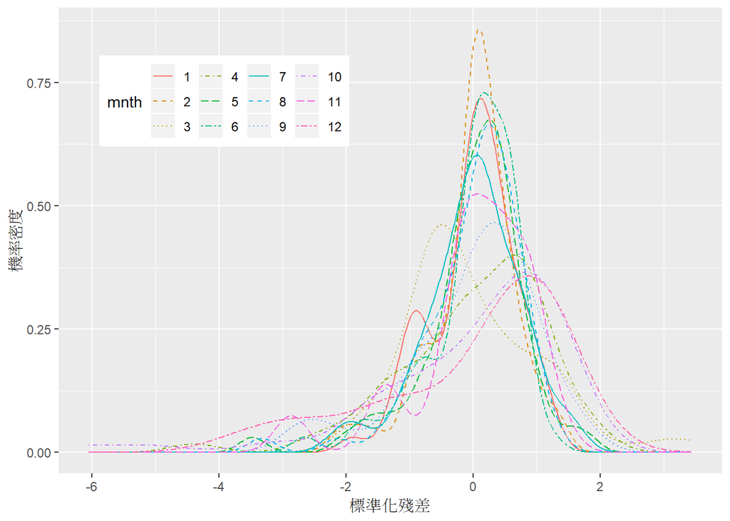

```r
ggplot(data = fit_m2, aes(x = scale(resid), col=mnth), group = mnth ) +
 stat_density(geom = 'path', position = 'identity', aes(linetype = mnth)) +
 scale_linetype_manual(values = 1:12) +
 labs(x = '標準化殘差', y = '機率密度') +
 theme(legend.position = c(.25, .8),legend.direction = "horizontal")
```

### 看看殘差的 Q-Q 圖，依 月份 檢視常態假設

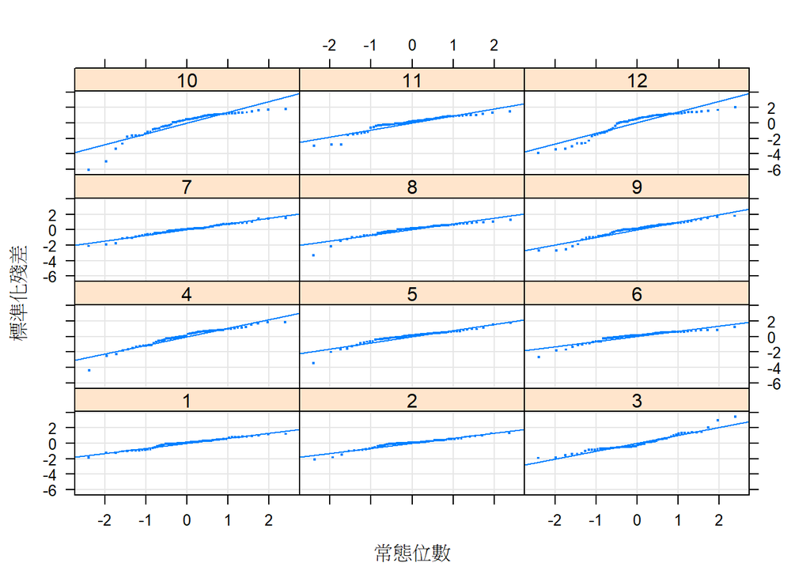

```r
require(lattice)
qqmath(~ scale(resid) | mnth, data = fit_m2, type = c('p', 'g', 'r'),
       xlab = '常態位數', ylab = '標準化殘差', layout = c(3, 4),
       pch = '.', cex = 2)
```

### 畫預測值與殘差的散佈圖，檢查線性與等分散假設

```r
require(MASS)
```

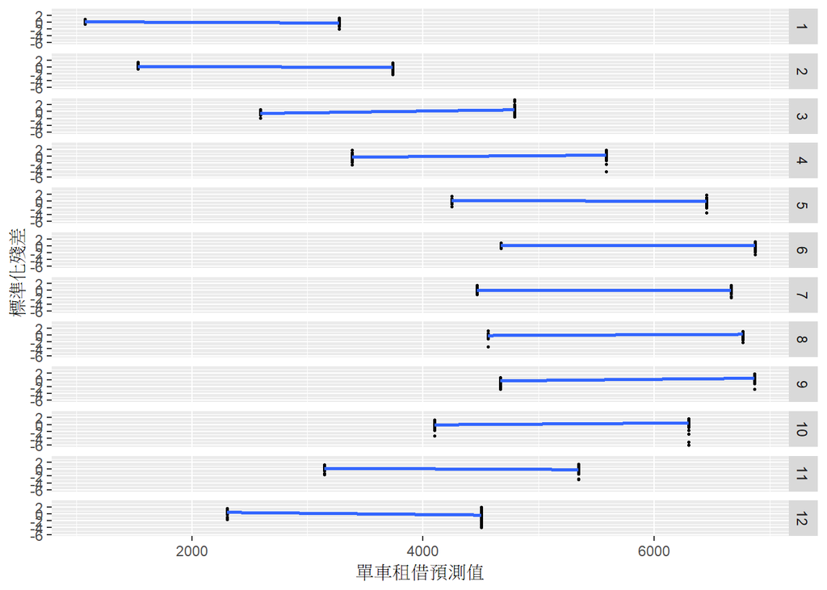

```r
ggplot(data = fit_m2, aes(x = fitted, y = scale(resid), group = mnth )) +
  geom_point(pch = 20, size = 1) +
  stat_smooth(method = 'rlm', se = F) +
  facet_grid(mnth ~ .) +
  labs(x = '單車租借預測值', y = '標準化殘差')
```

### 呈現影響值（影響估計結果過大的值）與標準化殘差

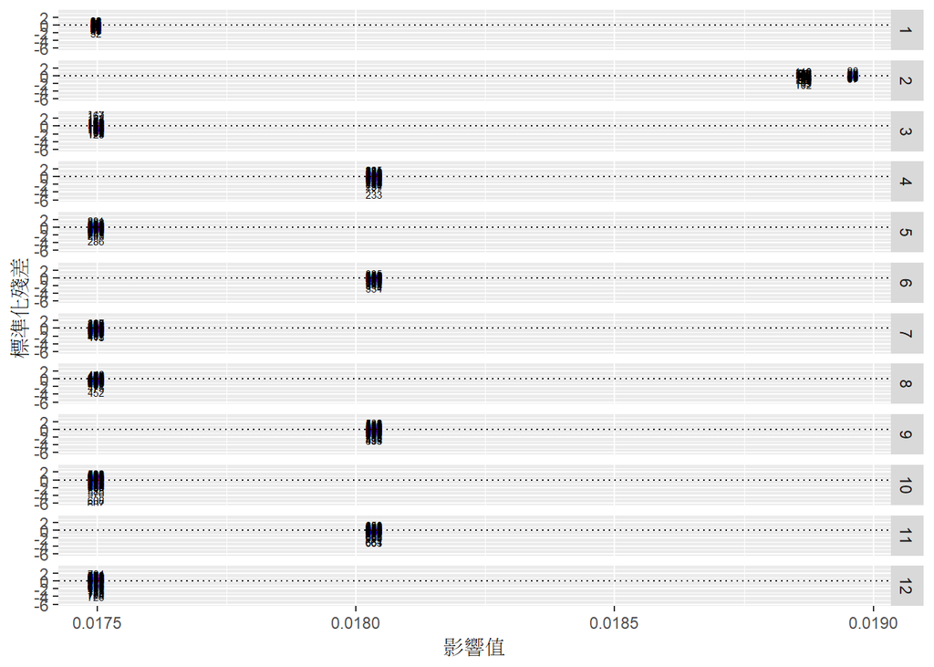

```r
ggplot(data = fit_m2, aes(x = infl, y = scale(resid), group = mnth)) +
 geom_text(aes(label = rownames(fit_m2)), cex = 2) +
 geom_hline(yintercept = 0, linetype = 'dotted') +
 facet_grid(mnth ~ .) +
 labs(x = '影響值', y = '標準化殘差')
```

### 看看影響值

```r
summary(influence(m2)$hat)
```

```
##    Min. 1st Qu.  Median    Mean 3rd Qu.    Max.
## 0.01750 0.01750 0.01750 0.01778 0.01803 0.01896
```

## Part E. 天氣型態 & 季 vs 單車租借量

### 以下觀察 季 是否與 單車租借量 有關

```r
#看不同 季 下的 單車租借量 平均數
tapply(df$cnt, df$season, mean)
```

```
##        1        2        3        4
## 2604.133 4992.332 5644.303 4728.163
```

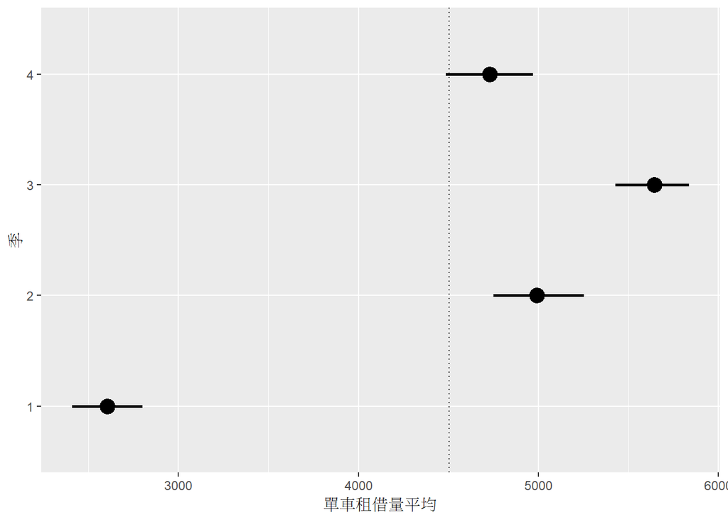

```r
library(Hmisc)

#同 季 下的 單車租借量 平均數，加上信賴區間
ggplot(data = df,
       aes(x = season, y = cnt)) +
  stat_summary(fun.data = 'mean_cl_boot', size = 1) +
  scale_y_continuous(breaks = seq(2000, 6000, by = 1000)) +
  geom_hline(yintercept = mean(df$cnt) ,
             linetype = 'dotted') +
  labs(x = '季', y = '單車租借量平均') +
  coord_flip()
```

### 在這裡我們推測 季 的效果 可能是 天氣型態 造成的，畫圖觀察看看

```r
anova(m1 <- lm(cnt ~ season, data = df))
```

```
## Analysis of Variance Table
##
## Response: cnt
##            Df     Sum Sq   Mean Sq F value    Pr(>F)
## season      3  950595868 316865289  128.77 < 2.2e-16 ***
## Residuals 727 1788939524   2460715
## ---
## Signif. codes:  0 '***' 0.001 '**' 0.01 '*' 0.05 '.' 0.1 ' ' 1
```

(註: season表組間, Residuals表組內, Mean Sq = Sum Sq / Df, F value = Mean Sq.mnth/Mean Sq.Residuals)  
> =>**p-value極小，季效果顯著**

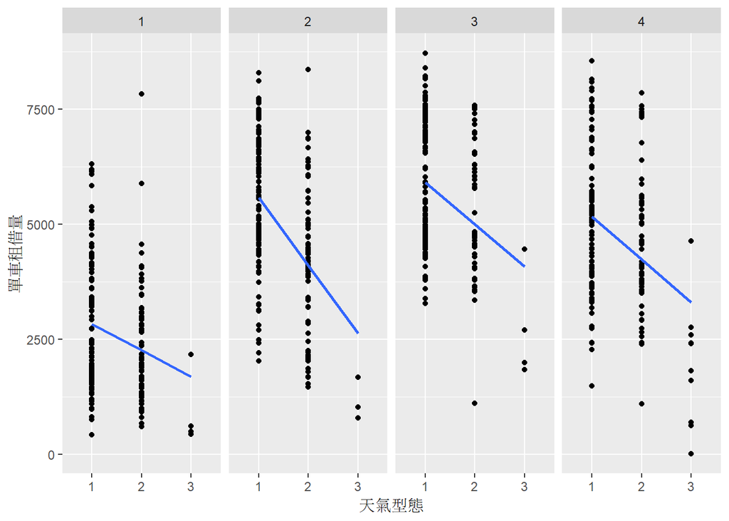

```r
ggplot(data = df,
       aes(group = season,
          y = cnt, x = weathersit)) +
  geom_point() +
  stat_smooth(method = 'lm', se = F) +
  stat_smooth(aes(group = season,
          y = cnt, x = weathersit),
          method = 'lm', se = F) +
  facet_grid( . ~  season) +
  labs(x = '天氣型態', y = '單車租借量')
```

### 利用以下 ANOVA 檢驗假設是否正確

```r
#把 天氣型態 加進模型
anova(m2 <- update(m1, . ~ . + weathersit, data = df))
```

```
## Analysis of Variance Table
##
## Response: cnt
##             Df     Sum Sq   Mean Sq F value    Pr(>F)
## season       3  950595868 316865289 148.650 < 2.2e-16 ***
## weathersit   2  243512285 121756142  57.119 < 2.2e-16 ***
## Residuals  725 1545427239   2131624
## ---
## Signif. codes:  0 '***' 0.001 '**' 0.01 '*' 0.05 '.' 0.1 ' ' 1
```

```r
#或許不是 季 而是 天氣型態 造成
anova(m3 <- update(m2, . ~ . - season,  data = df))
```

```
## Analysis of Variance Table
##
## Response: cnt
##             Df     Sum Sq   Mean Sq F value    Pr(>F)
## weathersit   2  271644573 135822286  40.066 < 2.2e-16 ***
## Residuals  728 2467890819   3389960
## ---
## Signif. codes:  0 '***' 0.001 '**' 0.01 '*' 0.05 '.' 0.1 ' ' 1
```

> =>**p-value極小，兩者效果都顯著**

### 將 ANOVA 結果做成圖表輸出，先計算一些需要的數據

```r
#將結果放在一個list中
res_lm <- lapply(list(m1, m2, m3), summary)
#比較在控制 天氣型態 下， 季 的效果
(res_lm[[2]]$r.sq - res_lm[[3]]$r.sq)/res_lm[[2]]$r.sq
```

```
## [1] 0.7725126
```

```r
anova(m3, m2)
```

```
## Analysis of Variance Table
##
## Model 1: cnt ~ weathersit
## Model 2: cnt ~ season + weathersit
##   Res.Df        RSS Df Sum of Sq      F    Pr(>F)
## 1    728 2467890819
## 2    725 1545427239  3 922463581 144.25 < 2.2e-16 ***
## ---
## Signif. codes:  0 '***' 0.001 '**' 0.01 '*' 0.05 '.' 0.1 ' ' 1
```

```r
#比較在控制 季 下， 天氣型態 的效果
(res_lm[[2]]$r.sq - res_lm[[1]]$r.sq)/res_lm[[1]]$r.sq
```

```
## [1] 0.256168
```

```r
anova(m1, m2)
```

```
## Analysis of Variance Table
##
## Model 1: cnt ~ season
## Model 2: cnt ~ season + weathersit
##   Res.Df        RSS Df Sum of Sq      F    Pr(>F)
## 1    727 1788939524
## 2    725 1545427239  2 243512285 57.119 < 2.2e-16 ***
## ---
## Signif. codes:  0 '***' 0.001 '**' 0.01 '*' 0.05 '.' 0.1 ' ' 1
```

### 正式畫圖

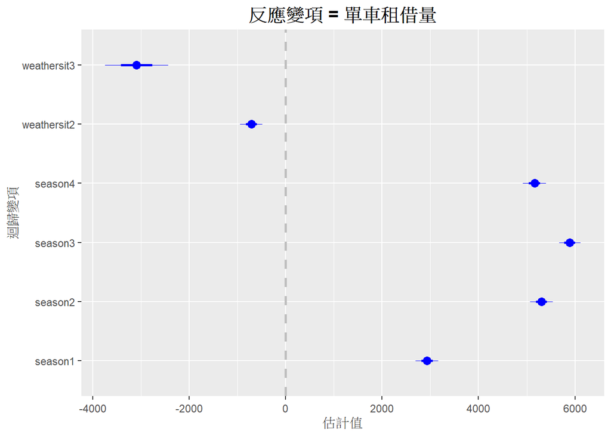

```r
require(coefplot)
m2 <- lm(cnt ~ season + weathersit -1, data = df) #(-1 將截距去除)
coefplot(m2, xlab = '估計值', ylab = '迴歸變項', title = '反應變項 = 單車租借量') +
  theme(axis.title = element_text(color = '#2d2d2d'),
        strip.text.x =  element_text(color='#2d2d2d',face='bold',size=10),
        plot.title = element_text(hjust=0.5,face='bold',size=15))
```

### 把資料與迴歸分析的預測值、殘差與影響度放進資料

```r
fit_m2 <- data.frame(df[, c(16, 3, 9)], fitted = fitted(m2), resid = resid(m2), infl = influence(m2)$hat )
```

### 依 季 疊合真實觀測值與預測值

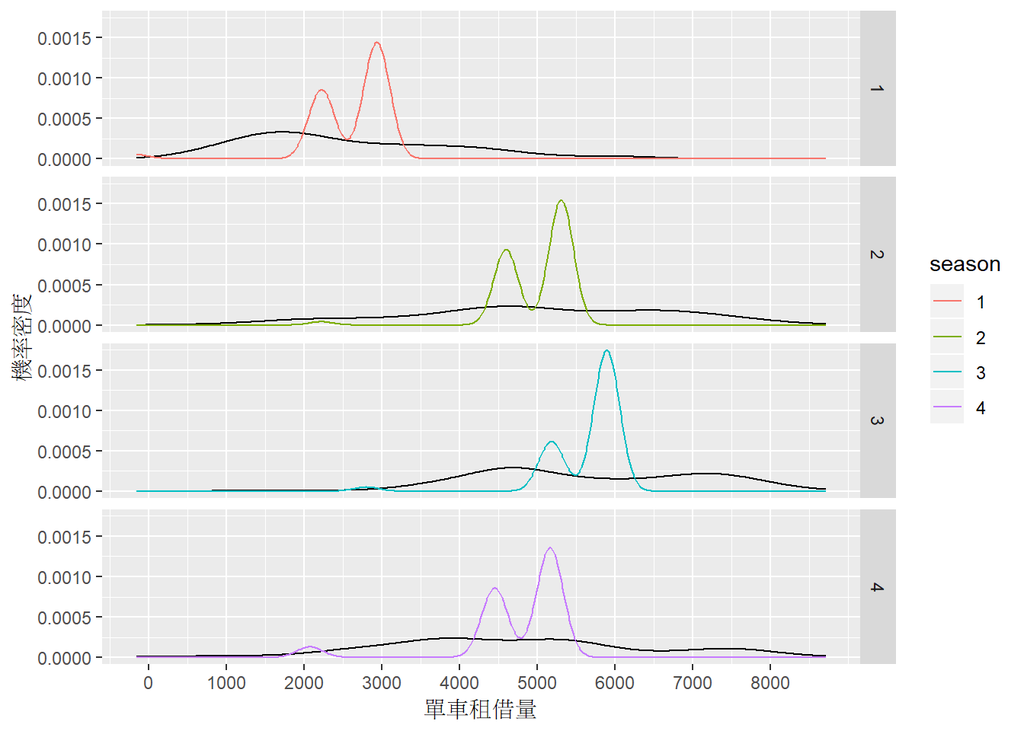

```r
ggplot(data = fit_m2, aes(x = cnt, group = season )) +
 stat_density(geom = 'path', position = 'identity') +
 stat_density(geom = 'path', position = 'identity', aes(x = fitted, col=season)) +
 facet_grid(season ~ .) +
 scale_x_continuous(breaks = seq(0, 8000, by = 1000))+
 labs(x = '單車租借量', y = '機率密度')
```

### 看殘差分配，依 季 檢視常態與變異數同質假設

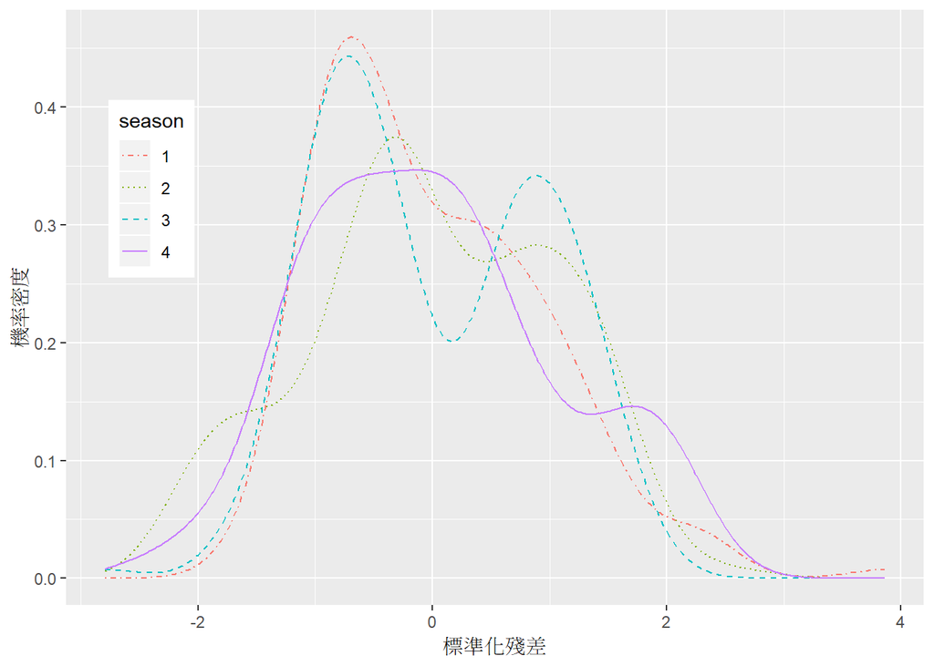

```r
ggplot(data = fit_m2, aes(x = scale(resid)), group = season ) +
 stat_density(geom = 'path', position = 'identity', aes(linetype = season, col=season)) +
 scale_linetype_manual(values = 4:1)  +
 labs(x = '標準化殘差', y = '機率密度') +
 theme(legend.position = c(.1, .7))
```

### 看看殘差的 Q-Q 圖，依 季 檢視常態假設

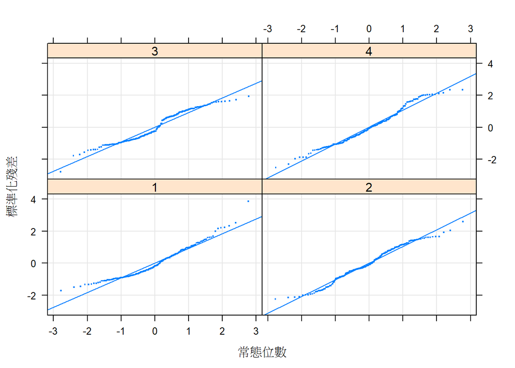

```r
require(lattice)
qqmath(~ scale(resid) | season, data = fit_m2, type = c('p', 'g', 'r'),
       xlab = '常態位數', ylab = '標準化殘差', layout = c(2, 2),
       pch = '.', cex = 2)
```

### 畫預測值與殘差的散佈圖，檢查線性與等分散假設

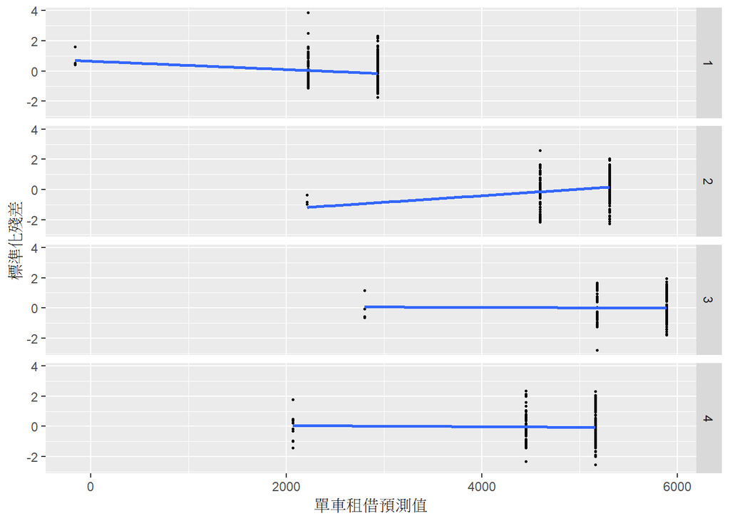

```r
require(MASS)
ggplot(data = fit_m2, aes(x = fitted, y = scale(resid), group = season )) +
  geom_point(pch = 20, size = 1) +
  stat_smooth(method = 'rlm', se = F) +
  facet_grid(season ~ .) +
  labs(x = '單車租借預測值', y = '標準化殘差')
```

### 呈現影響值（影響估計結果過大的值）與標準化殘差

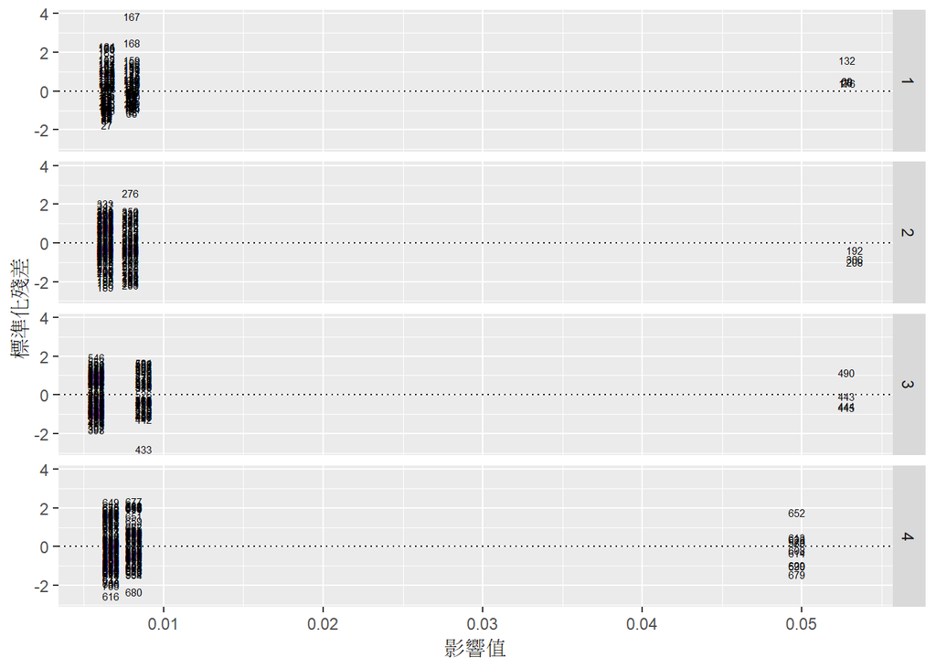

```r
ggplot(data = fit_m2, aes(x = infl, y = scale(resid), group = season)) +
 geom_text(aes(label = rownames(fit_m2)), cex = 2) +
 geom_hline(yintercept = 0, linetype = 'dotted') +
 facet_grid(season ~ .) +
 labs(x = '影響值', y = '標準化殘差')
```

### 看看影響值

```r
summary(influence(m2)$hat)
```

```
##     Min.  1st Qu.   Median     Mean  3rd Qu.     Max.
## 0.005776 0.006333 0.006706 0.008208 0.008022 0.053300
```

## Part F. 接下來分析資料集當中的其他變項是否和 單車租借量 有關

```r
df_cnt <- df[, c('cnt',
                 'temp', 'atemp', 'hum', 'windspeed')]
```

### 看看基本統計量

```r
colMeans(df_cnt)
```

```
##          cnt         temp        atemp          hum    windspeed
## 4504.3488372    0.4953848    0.4743540    0.6278941    0.1904862
```

### 呈現兩兩散佈圖

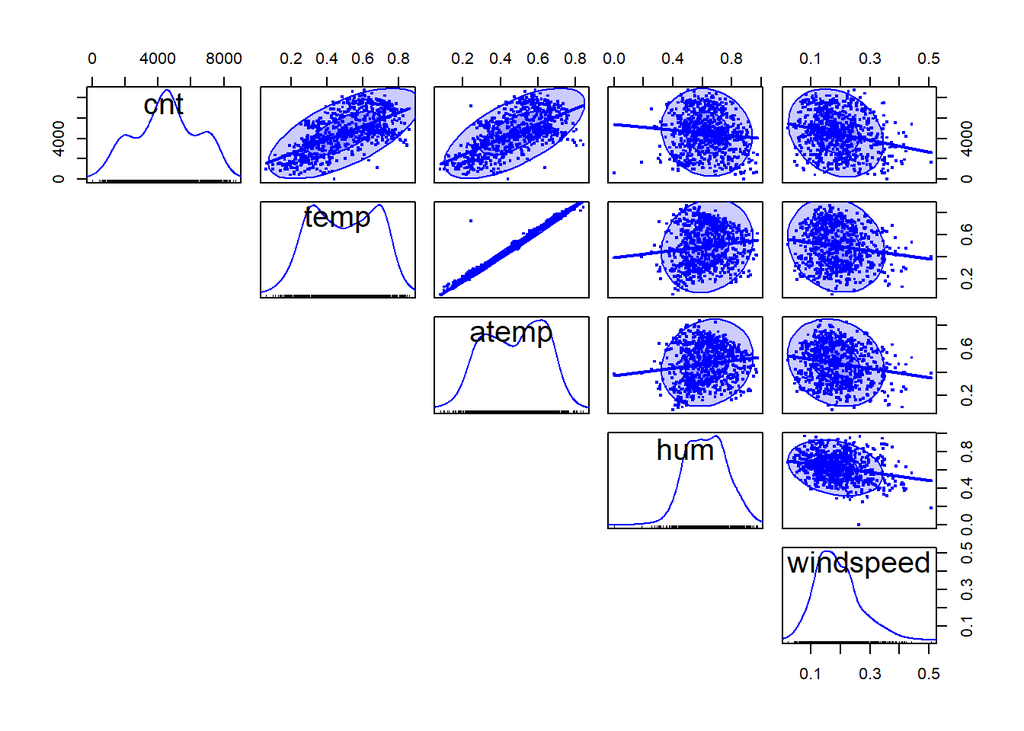

```r
require(heplots)
scatterplotMatrix(~ cnt + temp + atemp + hum + windspeed, data= df_cnt,
  pch = '.', cex = 3, smooth = FALSE, reg.line = FALSE, ellipse = TRUE,
  diagonal = 'none', lower.panel = NULL)
```

### 利用corrplot 套件，以圖形顯示相關性的大小

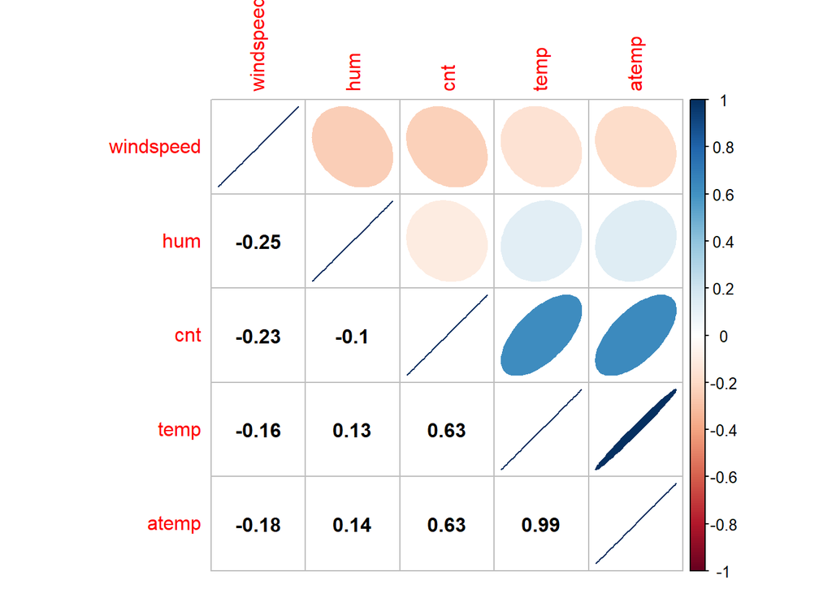

```r
require(corrplot)
corrplot(cor(df_cnt), method = 'ellipse', order = 'hclust', addrect = 5,
         type = 'upper', tl.pos = 'tpd')
corrplot(cor(df_cnt), add = TRUE, type = 'lower', method = 'number',
         order = 'hclust', col = 'black', diag = FALSE, tl.pos = 'n', cl.pos = 'n')
```

### 放進四個解釋變項

```r
summary(m4 <- lm(cnt ~ temp + atemp + hum + windspeed, data = df_cnt))
```

```
##
## Call:
## lm(formula = cnt ~ temp + atemp + hum + windspeed, data = df_cnt)
##
## Residuals:
##    Min     1Q Median     3Q    Max
##  -4855  -1046    -79   1055   3564
##
## Coefficients:
##             Estimate Std. Error t value Pr(>|t|)
## (Intercept)   3860.4      355.4  10.862  < 2e-16 ***
## temp          2111.8     2282.2   0.925   0.3551
## atemp         5139.2     2577.0   1.994   0.0465 *
## hum          -3149.1      384.0  -8.201 1.08e-15 ***
## windspeed    -4528.7      721.1  -6.280 5.82e-10 ***
## ---
## Signif. codes:  0 '***' 0.001 '**' 0.01 '*' 0.05 '.' 0.1 ' ' 1
##
## Residual standard error: 1422 on 726 degrees of freedom
## Multiple R-squared:  0.4638, Adjusted R-squared:  0.4609
## F-statistic:   157 on 4 and 726 DF,  p-value: < 2.2e-16
```

> => **氣溫不顯著但體感溫度、濕度、風速是顯著的，說明人體感受才是影響騎車意願比較大的原因**

### 來看看效果如何

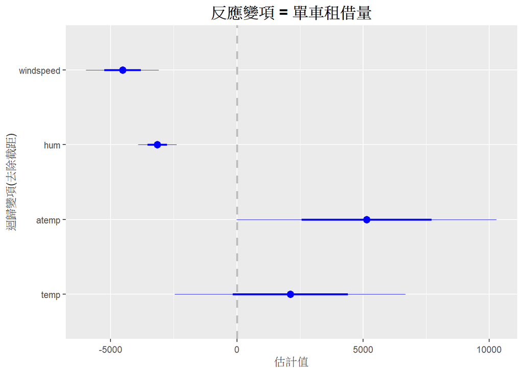

```r
coefplot(m4, predictors = c('temp', 'atemp', 'hum', 'windspeed'),
 xlab = '估計值', ylab = '迴歸變項(去除截距)', title = '反應變項 = 單車租借量') +
  theme(axis.title = element_text(color = '#2d2d2d'),
        strip.text.x = element_text(color='#2d2d2d',face='bold',size=10),
        plot.title = element_text(hjust=0.5,face='bold',size=15))
```

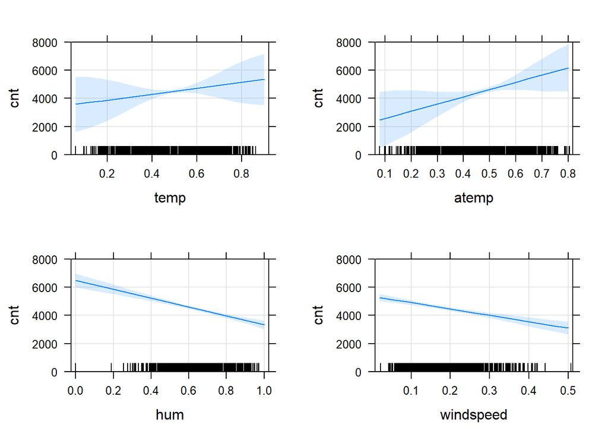

```r
library(effects)
plot(allEffects(m4), main = '', ylim = c(0, 8000), grid = T)
```

### 利用 lm.beta 套件，計算標準化迴歸係數

```r
library(lm.beta)
summary(lm.beta(m4))
```

```
##
## Call:
## lm(formula = cnt ~ temp + atemp + hum + windspeed, data = df_cnt)
##
## Residuals:
##    Min     1Q Median     3Q    Max
##  -4855  -1046    -79   1055   3564
##
## Coefficients:
##               Estimate Standardized Std. Error t value Pr(>|t|)
## (Intercept)  3860.3685       0.0000   355.3890  10.862  < 2e-16 ***
## temp         2111.8136       0.1995  2282.1976   0.925   0.3551
## atemp        5139.1524       0.4323  2576.9972   1.994   0.0465 *
## hum         -3149.1098      -0.2315   383.9943  -8.201 1.08e-15 ***
## windspeed   -4528.6748      -0.1812   721.0854  -6.280 5.82e-10 ***
## ---
## Signif. codes:  0 '***' 0.001 '**' 0.01 '*' 0.05 '.' 0.1 ' ' 1
##
## Residual standard error: 1422 on 726 degrees of freedom
## Multiple R-squared:  0.4638, Adjusted R-squared:  0.4609
## F-statistic:   157 on 4 and 726 DF,  p-value: < 2.2e-16
```

### 看看控制 體感溫度、濕度、風速 後，氣溫的效果

```r
summary(m5 <- update(m4, . ~ . - temp , data = df_cnt))
```

```
##
## Call:
## lm(formula = cnt ~ atemp + hum + windspeed, data = df_cnt)
##
## Residuals:
##    Min     1Q Median     3Q    Max
##  -4890  -1043    -82   1072   4384
##
## Coefficients:
##             Estimate Std. Error t value Pr(>|t|)
## (Intercept)   3774.0      342.9  11.007  < 2e-16 ***
## atemp         7504.1      330.2  22.723  < 2e-16 ***
## hum          -3167.5      383.4  -8.261 6.84e-16 ***
## windspeed    -4411.7      709.8  -6.215 8.64e-10 ***
## ---
## Signif. codes:  0 '***' 0.001 '**' 0.01 '*' 0.05 '.' 0.1 ' ' 1
##
## Residual standard error: 1422 on 727 degrees of freedom
## Multiple R-squared:  0.4632, Adjusted R-squared:  0.461
## F-statistic: 209.1 on 3 and 727 DF,  p-value: < 2.2e-16
```

```r
anova(m5, m4)
```

```
## Analysis of Variance Table
##
## Model 1: cnt ~ atemp + hum + windspeed
## Model 2: cnt ~ temp + atemp + hum + windspeed
##   Res.Df        RSS Df Sum of Sq      F Pr(>F)
## 1    727 1470583292
## 2    726 1468850901  1   1732390 0.8563 0.3551
```

> =>**決定移除temp項目**

## Part G. 組合嘗試

> 單車租借量 ~ 體感溫度 + 濕度 + 風速 + 年份

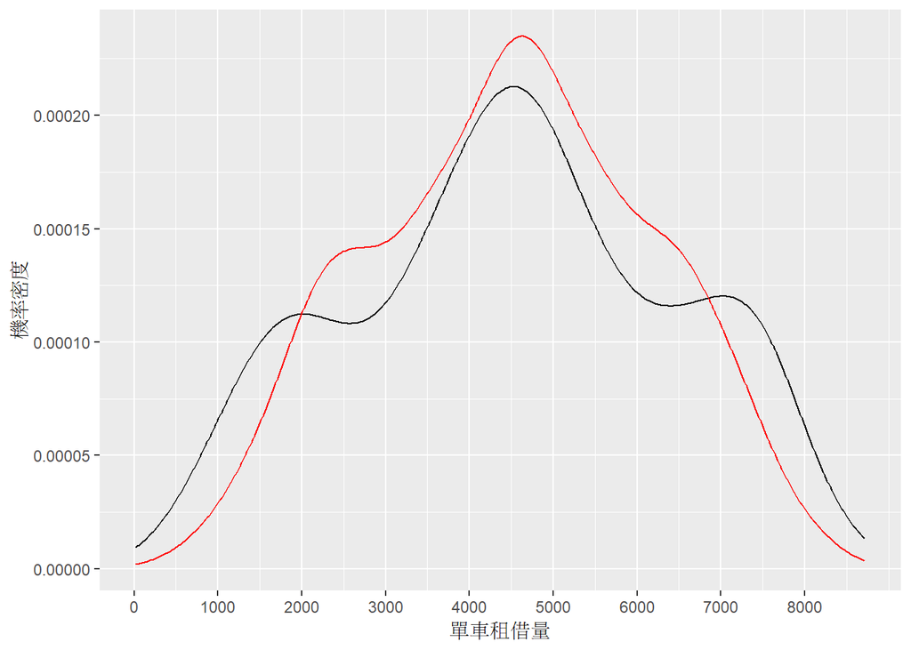

```r
m5 <- lm(cnt ~ atemp + hum + windspeed + yr, data = df)
fit_m5 <- data.frame(df[, c(16, 11, 12, 13, 4)], fitted = fitted(m5), resid = resid(m5), infl = influence(m5)$hat)

ggplot(data = fit_m5, aes(x = cnt)) +
 stat_density(geom = 'path', position = 'identity') +
 stat_density(geom = 'path', position = 'identity', col='red', aes(x = fitted)) +
 scale_x_continuous(breaks = seq(0, 8000, by = 1000)) +
 labs(x = '單車租借量', y = '機率密度')
```

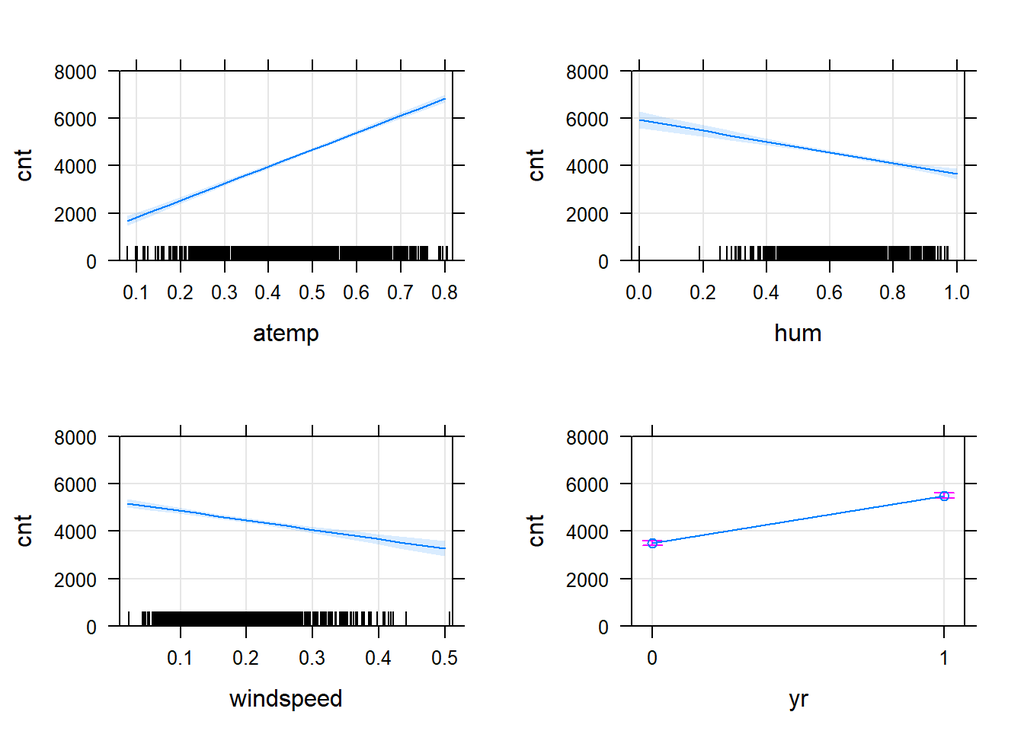

```r
plot(allEffects(m5), main = '', ylim = c(0, 8000), grid = T)
```

```r
summary(lm.beta(m5))
```

```
##
## Call:
## lm(formula = cnt ~ atemp + hum + windspeed + yr, data = df)
##
## Residuals:
##     Min      1Q  Median      3Q     Max
## -3993.5  -613.3    48.3   748.7  3332.2
##
## Coefficients:
##               Estimate Standardized Std. Error t value Pr(>|t|)
## (Intercept)  2295.0450       0.0000   250.6982   9.155  < 2e-16 ***
## atemp        7147.3855       0.6012   235.8062  30.310  < 2e-16 ***
## hum         -2272.4878      -0.1671   275.4254  -8.251 7.39e-16 ***
## windspeed   -3987.4852      -0.1595   506.2932  -7.876 1.24e-14 ***
## yr1          2007.9642       0.5186    75.6515  26.542  < 2e-16 ***
## ---
## Signif. codes:  0 '***' 0.001 '**' 0.01 '*' 0.05 '.' 0.1 ' ' 1
##
## Residual standard error: 1014 on 726 degrees of freedom
## Multiple R-squared:  0.7276, Adjusted R-squared:  0.7261
## F-statistic: 484.7 on 4 and 726 DF,  p-value: < 2.2e-16
```

> 單車租借量 ~ 體感溫度 + 年份 + 天氣型態

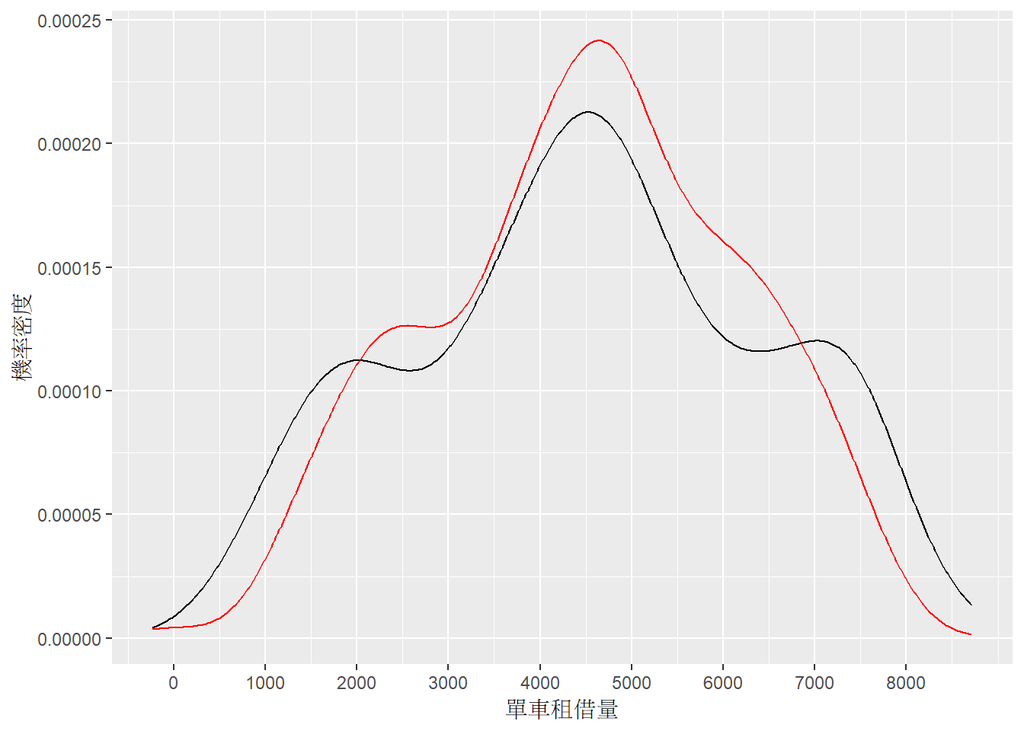

```r
m6 <- lm(cnt ~ atemp + yr + weathersit , data = df)
fit_m6 <- data.frame(df[, c(16, 11, 4, 9)], fitted = fitted(m6), resid = resid(m6), infl = influence(m6)$hat)

ggplot(data = fit_m6, aes(x = cnt)) +
 stat_density(geom = 'path', position = 'identity') +
 stat_density(geom = 'path', position = 'identity', col='red', aes(x = fitted)) +
 scale_x_continuous(breaks = seq(0, 8000, by = 1000)) +
 labs(x = '單車租借量', y = '機率密度')
```

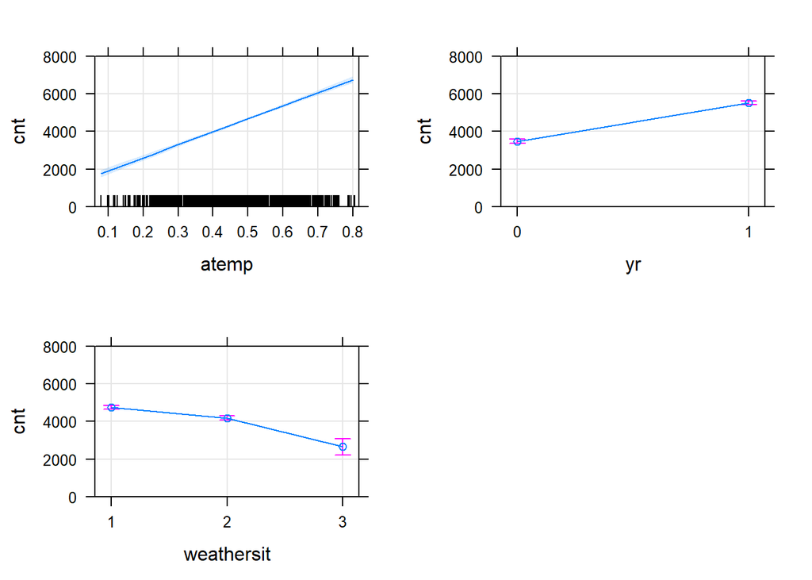

```r
plot(allEffects(m6), main = '', ylim = c(0, 8000), grid = T)
```

```r
summary(lm.beta(m6))
```

```
##
## Call:
## lm(formula = cnt ~ atemp + yr + weathersit, data = df)
##
## Residuals:
##     Min      1Q  Median      3Q     Max
## -3418.2  -610.2     2.3   742.0  2980.8
##
## Coefficients:
##               Estimate Standardized Std. Error t value Pr(>|t|)
## (Intercept)   453.2356       0.0000   126.1838   3.592  0.00035 ***
## atemp        6919.9915       0.5821   230.0345  30.082  < 2e-16 ***
## yr1          2036.5538       0.5260    74.5763  27.308  < 2e-16 ***
## weathersit2  -565.3703      -0.1381    79.5755  -7.105 2.88e-12 ***
## weathersit3 -2090.2218      -0.1804   225.3663  -9.275  < 2e-16 ***
## ---
## Signif. codes:  0 '***' 0.001 '**' 0.01 '*' 0.05 '.' 0.1 ' ' 1
##
## Residual standard error: 1004 on 726 degrees of freedom
## Multiple R-squared:  0.7326, Adjusted R-squared:  0.7311
## F-statistic: 497.3 on 4 and 726 DF,  p-value: < 2.2e-16
```

> 單車租借量 ~ 體感溫度 + 年份 + 天氣型態 + 星期 + 工作日

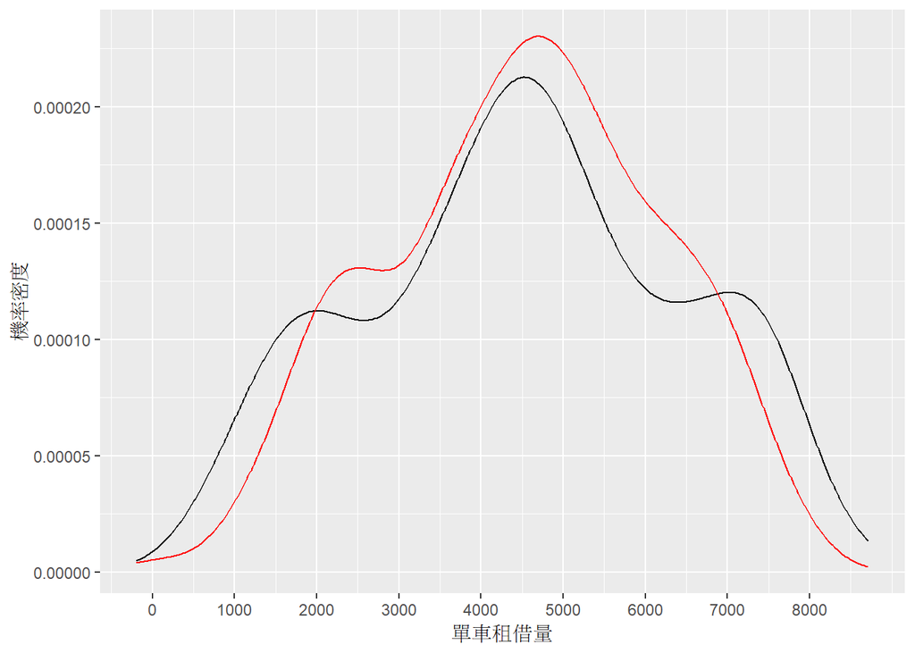

```r
m7 <- lm(cnt ~ atemp + yr + weathersit + weekday + workingday, data = df)
fit_m7 <- data.frame(df[, c(16, 11, 4, 9, 7, 8)], fitted = fitted(m7), resid = resid(m7), infl = influence(m7)$hat)

ggplot(data = fit_m7, aes(x = cnt)) +
 stat_density(geom = 'path', position = 'identity') +
 stat_density(geom = 'path', position = 'identity', col='red', aes(x = fitted)) +
 scale_x_continuous(breaks = seq(0, 8000, by = 1000)) +
 labs(x = '單車租借量', y = '機率密度')
```

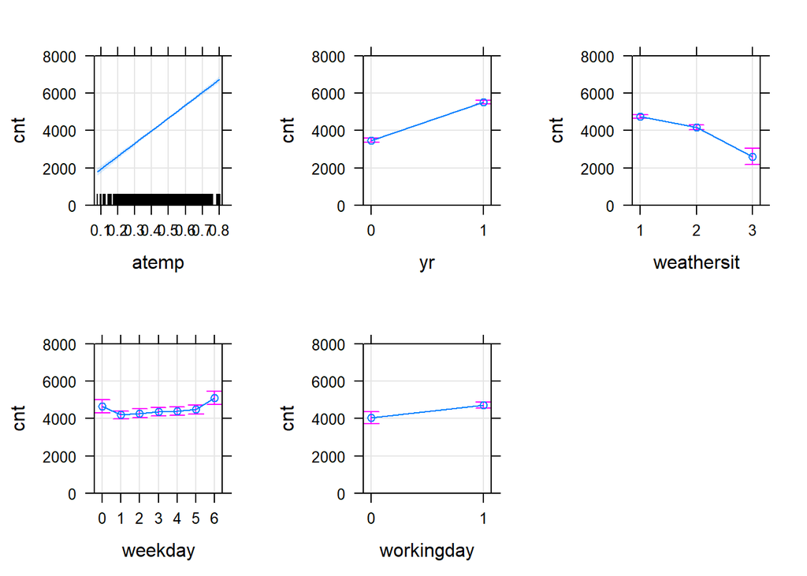

```r
plot(allEffects(m7), main = '', ylim = c(0, 8000), grid = T)
```

```r
summary(lm.beta(m7))
```

```
##
## Call:
## lm(formula = cnt ~ atemp + yr + weathersit + weekday + workingday,
##     data = df)
##
## Residuals:
##     Min      1Q  Median      3Q     Max
## -3370.1  -599.6   -14.0   729.6  2768.0
##
## Coefficients:
##               Estimate Standardized Std. Error t value Pr(>|t|)
## (Intercept)  1.863e+02    0.000e+00  1.505e+02   1.238  0.21623
## atemp        6.880e+03    5.788e-01  2.272e+02  30.283  < 2e-16 ***
## yr1          2.039e+03    5.266e-01  7.348e+01  27.748  < 2e-16 ***
## weathersit2 -5.861e+02   -1.432e-01  7.864e+01  -7.453 2.63e-13 ***
## weathersit3 -2.146e+03   -1.851e-01  2.239e+02  -9.584  < 2e-16 ***
## weekday1    -4.627e+02   -8.382e-02  2.389e+02  -1.937  0.05313 .
## weekday2    -3.798e+02   -6.853e-02  2.645e+02  -1.436  0.15156
## weekday3    -2.963e+02   -5.346e-02  2.647e+02  -1.120  0.26329
## weekday4    -2.556e+02   -4.612e-02  2.627e+02  -0.973  0.33088
## weekday5    -1.753e+02   -3.163e-02  2.628e+02  -0.667  0.50508
## weekday6     4.469e+02    8.096e-02  1.368e+02   3.267  0.00114 **
## workingday1  6.623e+02    1.590e-01  2.288e+02   2.894  0.00392 **
## ---
## Signif. codes:  0 '***' 0.001 '**' 0.01 '*' 0.05 '.' 0.1 ' ' 1
##
## Residual standard error: 989.7 on 719 degrees of freedom
## Multiple R-squared:  0.7429, Adjusted R-squared:  0.739
## F-statistic: 188.9 on 11 and 719 DF,  p-value: < 2.2e-16
```

### 看控制其他項目，星期的效果

```r
summary(m8 <- update(m7, . ~ . - weekday , data = df))
```

```
##
## Call:
## lm(formula = cnt ~ atemp + yr + weathersit + workingday, data = df)
##
## Residuals:
##     Min      1Q  Median      3Q     Max
## -3461.5  -610.8   -22.9   741.7  2910.7
##
## Coefficients:
##             Estimate Std. Error t value Pr(>|t|)
## (Intercept)   346.41     134.07   2.584  0.00997 **
## atemp        6888.10     229.77  29.978  < 2e-16 ***
## yr1          2036.83      74.36  27.393  < 2e-16 ***
## weathersit2  -576.38      79.48  -7.252 1.06e-12 ***
## weathersit3 -2110.79     224.88  -9.386  < 2e-16 ***
## workingday1   184.39      79.97   2.306  0.02141 *
## ---
## Signif. codes:  0 '***' 0.001 '**' 0.01 '*' 0.05 '.' 0.1 ' ' 1
##
## Residual standard error: 1002 on 725 degrees of freedom
## Multiple R-squared:  0.7346, Adjusted R-squared:  0.7327
## F-statistic: 401.2 on 5 and 725 DF,  p-value: < 2.2e-16
```

```r
anova(m8, m7)
```

```
## Analysis of Variance Table
##
## Model 1: cnt ~ atemp + yr + weathersit + workingday
## Model 2: cnt ~ atemp + yr + weathersit + weekday + workingday
##   Res.Df       RSS Df Sum of Sq      F    Pr(>F)
## 1    725 727206844
## 2    719 704265231  6  22941613 3.9036 0.0007598 ***
## ---
## Signif. codes:  0 '***' 0.001 '**' 0.01 '*' 0.05 '.' 0.1 ' ' 1
```